# Lista 2

# Streszczenie

Celem niniejszego sprawozdania jest zbudowanie modelu klasyfikacyjnego `XGBoost` do przewidywania, **czy klient zdecyduje się na lokatę terminową**.  
Model zbudujemy na podstawie cech demograficznych i informacji o kontakcie marketingowym z klientem.

Sprawozdanie zostało opracowane na podstawie pliku `dane_list2.csv`.

Dane znajdujące się w pliku dotyczą kampanii marketingowych portugalskiej instytucji bankowej.  
Kampanie te były prowadzone telefonicznie.  
Często konieczne było wykonanie więcej niż jednego kontaktu z tym samym klientem, aby ocenić, czy produkt (lokata terminowa) zostanie subskrybowany, czy nie.  
Zbiór danych zawiera wszystkie przykłady uporządkowane chronologicznie (od maja 2008 do listopada 2010).

Przy czym, warto zaznaczyć, że za obserwację w próbach uznajemy indywidualnego klienta banku ( jeden wiersz w danych odpowiada jednemu klientowi).

Do konstrukcji modelu wykorzystane zostaną następujące zmienne:

- **Dane klienta banku**
1. `age` – wiek (numeryczna),
2. `job` – rodzaj pracy (kategoryczna: "admin.", "unknown", "unemployed", "management", "housemaid", "entrepreneur", "student", "blue-collar", "self-employed", "retired", "technician", "services"),
3. `marital` – stan cywilny (kategoryczna: "married" – zamężny/żonaty, "divorced" – rozwiedziony/wdowiec, "single" – singiel),
4. `education` – poziom wykształcenia (kategoryczna: "unknown", "secondary", "primary", "tertiary"),
5. `default` – czy klient ma zaległości w spłacie kredytu? (binarna: "yes", "no"),
6. `balance` – średnie roczne saldo na koncie klienta (w euro) (numeryczna),
7. `housing` – czy klient ma kredyt hipoteczny? (binarna: "yes", "no"),
8. `loan` – czy klient ma kredyt gotówkowy? (binarna: "yes", "no"),
- **Informacje o ostatnim kontakcie w bieżącej kampanii**
10. `contact` – typ komunikacji (kategoryczna: "unknown", "telephone", "cellular"),
11. `day` – dzień ostatniego kontaktu w miesiącu (numeryczna),
12. `month` – miesiąc ostatniego kontaktu (kategoryczna: "jan", "feb", "mar", ..., "nov", "dec"),
13. `duration` – czas trwania ostatniego kontaktu (w sekundach) (numeryczna),
- **Inne zmienne**
14. `campaign` – liczba kontaktów wykonanych w tej kampanii dla danego klienta (numeryczna, obejmuje ostatni kontakt),
15. `pdays` – liczba dni od ostatniego kontaktu klienta w poprzedniej kampanii (numeryczna, -1 oznacza, że klient nie był wcześniej kontaktowany),
16. `previous` – liczba kontaktów wykonanych przed tą kampanią dla danego klienta (numeryczna),
17. `poutcome` – wynik poprzedniej kampanii marketingowej (kategoryczna: "unknown", "other", "failure", "success").

W tym miejscu warto również zaznaczyć, że sprawozdanie składać się będzie z dwóch części.  
W pierwszej z nich skupimy się na szczegółowej analizie każdej z wymienionych zmiennych, natomiast w drugiej przystąpimy do budowy modelu.

# Wstęp

Na wstępie wyjaśnijmy krótko, czym jest wspomniany wyżej model:

**XGBoost (Extreme Gradient Boosting)** - to model nadzorowanego uczenia maszynowego oparty na metodzie boostingu drzew decyzyjnych. Działa poprzez tworzenie wielu prostych drzew, z których każde uczy się na błędach poprzednich, co prowadzi do coraz lepszych prognoz. Służy do rozwiązywania problemów klasyfikacji i regresji, szczególnie w analizie danych tabelarycznych.  
Znany jest z wysokiej skuteczności i szybkości działania.

```python
import pandas as pd
from sklearn.preprocessing import LabelEncoder
from sklearn.model_selection import train_test_split
import matplotlib.pyplot as plt
import numpy as np
import warnings
```

```python
dane = pd.read_csv("dane_list2.csv",sep=";")
```

```python
dane = dane.reset_index()
dane = dane.rename(columns={"index": 'customer_id'})
```

```python
warnings.filterwarnings("ignore")
dane2 = dane.copy()
dane2["y"] = dane2["y"].replace("no", 0)
dane2["y"] = dane2["y"].replace("yes", 1)
```

```python
encoder = LabelEncoder()
for col in dane2.select_dtypes(include='object').columns:
    dane2[col] = encoder.fit_transform(dane2[col])
```

```python
X_train, X_test, y_train, y_test =train_test_split(dane2[[i for i in dane2.columns if i not in ['y','customer_id']]],
                                               dane2.y,
                                               test_size=0.2,
                                               random_state=20)
```

# Część I - Eksploracyjna analiza danych

Celem tej części jest przeprowadzenie szczegółowej eksploracyjnej analizy danych, która pozwala na lepsze zrozumienie struktury i charakterystyki dostępnych zmiennych przed przystąpieniem do budowy modelu predykcyjnego.

Analiza zostanie przeprowadzona osobno dla każdej zmiennej, z uwzględnieniem jej znaczenia i roli w zbiorze danych.  
W szczególności zbadane zostaną:

- rozkłady zmiennych,
- statystyki opisowe,
- występowanie braków danych,
- wartości odstające,
- korelacje między zmiennymi,
- oraz zależność zmiennych objaśniających względem zmiennej wynikowej.

```python
def klasyfikuj_zmienne(df, threshold_kat=12):
    klasyfikacja = {"binarne": [], "kategoryczne": [], "numeryczne": []}

    for kolumna in df.columns:
        unikalne = df[kolumna].nunique()

        if unikalne == 2:
            klasyfikacja["binarne"].append(kolumna)
        elif unikalne <= threshold_kat:
            klasyfikacja["kategoryczne"].append(kolumna)
        else:
            klasyfikacja["numeryczne"].append(kolumna)

    return klasyfikacja
```

## Puste wartości i duplikaty

Analizę rozpoczniemy od sprawdzenia dwóch kluczowych kwestii, tj. czy w danych występują duplikaty oraz czy wśród wartości zmiennych występują takie, które są puste.  
Ich obecność mogłaby zniekształcić ogólny obraz danych i negatywnie wpłynąć na dalszą analizę.  
Wyniki prezentujemy w poniższych tabelach.

```python
raport1 = pd.DataFrame({
    'TRAIN': X_train.isna().sum(),
    'TEST':X_test.isna().sum()
}).T

raport2 = pd.DataFrame({
    "TRAIN": [X_train.duplicated().sum()],
    "TEST": [X_test.duplicated().sum()]
}, index=["Duplikaty"]).T

raport1.style.set_table_styles([
        {'selector': 'td, th', 'props': [('border', '1px solid black')]},
        {'selector': 'tr:nth-child(even)', 'props': [('background-color', 'lightgray')]},
        {'selector': 'tr:nth-child(odd)', 'props': [('background-color', 'white')]},
        {'selector': 'caption', 'props': [('font-weight', 'bold')]},
    ]).set_caption("Liczba wartości pustych dla każdej zmiennej").set_table_attributes("style='margin:auto; font-size:14px'")
```

Liczba wartości pustych dla każdej zmiennej

|  | age | job | marital | education | default | balance | housing | loan | contact | day | month | duration | campaign | pdays | previous | poutcome |
| --- | --- | --- | --- | --- | --- | --- | --- | --- | --- | --- | --- | --- | --- | --- | --- | --- |
| TRAIN | 0 | 0 | 0 | 0 | 0 | 0 | 0 | 0 | 0 | 0 | 0 | 0 | 0 | 0 | 0 | 0 |
| TEST | 0 | 0 | 0 | 0 | 0 | 0 | 0 | 0 | 0 | 0 | 0 | 0 | 0 | 0 | 0 | 0 |

```python
raport2.style.set_table_styles([
        {'selector': 'td, th', 'props': [('border', '1px solid black')]},
        {'selector': 'tr:nth-child(even)', 'props': [('background-color', 'lightgray')]},
        {'selector': 'tr:nth-child(odd)', 'props': [('background-color', 'white')]},
    {'selector': 'caption','props':[('font-weight','bold')]},
    ]).set_table_attributes("style='margin:auto; font-size:16px'").set_caption("Liczba duplikatów")
```

Liczba duplikatów

|  | Duplikaty |
| --- | --- |
| TRAIN | 0 |
| TEST | 0 |

Dane nie zawierają duplikatów ani brakujących wartości, co pozwala na bezpośrednie przejście do dalszej analizy.

## Statystyki opisowe

Kolejnym krokiem analizy jest obliczenie statystyk opisowych, które pozwalają ocenić podstawowe charakterystyki zmiennych, takie jak średnia czy odchylenie standardowe.

```python
X_train.describe().T.style.set_table_styles([
        {'selector': 'td, th', 'props': [('border', '1px solid black')]},
        {'selector': 'caption', 'props': [('font-weight', 'bold')]},
    ]).set_table_attributes("style='margin:auto; font-size:14px'").background_gradient(cmap='Greys', low=1, high=0.5).set_caption("Wyniki dla zbioru danych TRAIN")
```

Wyniki dla zbioru danych TRAIN

|  | count | mean | std | min | 25% | 50% | 75% | max |
| --- | --- | --- | --- | --- | --- | --- | --- | --- |
| age | 36168.000000 | 40.947716 | 10.630946 | 18.000000 | 33.000000 | 39.000000 | 48.000000 | 94.000000 |
| job | 36168.000000 | 4.338670 | 3.276785 | 0.000000 | 1.000000 | 4.000000 | 7.000000 | 11.000000 |
| marital | 36168.000000 | 1.167054 | 0.606931 | 0.000000 | 1.000000 | 1.000000 | 2.000000 | 2.000000 |
| education | 36168.000000 | 1.220941 | 0.746518 | 0.000000 | 1.000000 | 1.000000 | 2.000000 | 3.000000 |
| default | 36168.000000 | 0.018663 | 0.135333 | 0.000000 | 0.000000 | 0.000000 | 0.000000 | 1.000000 |
| balance | 36168.000000 | 1365.310136 | 3035.755412 | -8019.000000 | 70.000000 | 445.000000 | 1431.000000 | 98417.000000 |
| housing | 36168.000000 | 0.556929 | 0.496755 | 0.000000 | 0.000000 | 1.000000 | 1.000000 | 1.000000 |
| loan | 36168.000000 | 0.161330 | 0.367841 | 0.000000 | 0.000000 | 0.000000 | 0.000000 | 1.000000 |
| contact | 36168.000000 | 0.641340 | 0.898281 | 0.000000 | 0.000000 | 0.000000 | 2.000000 | 2.000000 |
| day | 36168.000000 | 15.814919 | 8.323935 | 1.000000 | 8.000000 | 16.000000 | 21.000000 | 31.000000 |
| month | 36168.000000 | 5.531243 | 3.004373 | 0.000000 | 3.000000 | 6.000000 | 8.000000 | 11.000000 |
| duration | 36168.000000 | 258.805187 | 259.943461 | 0.000000 | 103.000000 | 180.000000 | 319.000000 | 4918.000000 |
| campaign | 36168.000000 | 2.759207 | 3.052023 | 1.000000 | 1.000000 | 2.000000 | 3.000000 | 51.000000 |
| pdays | 36168.000000 | 40.295233 | 100.450310 | -1.000000 | -1.000000 | -1.000000 | -1.000000 | 871.000000 |
| previous | 36168.000000 | 0.582393 | 2.387158 | 0.000000 | 0.000000 | 0.000000 | 0.000000 | 275.000000 |
| poutcome | 36168.000000 | 2.559970 | 0.988751 | 0.000000 | 3.000000 | 3.000000 | 3.000000 | 3.000000 |

```python
X_test.describe().T.style.set_table_styles([
        {'selector': 'td, th', 'props': [('border', '1px solid black')]},
        {'selector': 'caption', 'props': [('font-weight', 'bold')]},
    ]).set_table_attributes("style='margin:auto; font-size:14px'").background_gradient(cmap='Greys', low=1, high=0.5).set_caption("Wyniki dla zbioru danych TEST")
```

Wyniki dla zbioru danych TEST

|  | count | mean | std | min | 25% | 50% | 75% | max |
| --- | --- | --- | --- | --- | --- | --- | --- | --- |
| age | 9043.000000 | 40.890191 | 10.570353 | 18.000000 | 33.000000 | 39.000000 | 48.000000 | 95.000000 |
| job | 9043.000000 | 4.344134 | 3.256271 | 0.000000 | 1.000000 | 4.000000 | 7.000000 | 11.000000 |
| marital | 9043.000000 | 1.170408 | 0.613424 | 0.000000 | 1.000000 | 1.000000 | 2.000000 | 2.000000 |
| education | 9043.000000 | 1.240296 | 0.753730 | 0.000000 | 1.000000 | 1.000000 | 2.000000 | 3.000000 |
| default | 9043.000000 | 0.015482 | 0.123465 | 0.000000 | 0.000000 | 0.000000 | 0.000000 | 1.000000 |
| balance | 9043.000000 | 1350.121088 | 3080.679425 | -4057.000000 | 81.000000 | 460.000000 | 1413.500000 | 102127.000000 |
| housing | 9043.000000 | 0.551476 | 0.497371 | 0.000000 | 0.000000 | 1.000000 | 1.000000 | 1.000000 |
| loan | 9043.000000 | 0.155811 | 0.362696 | 0.000000 | 0.000000 | 0.000000 | 0.000000 | 1.000000 |
| contact | 9043.000000 | 0.635851 | 0.896666 | 0.000000 | 0.000000 | 0.000000 | 2.000000 | 2.000000 |
| day | 9043.000000 | 15.772421 | 8.317013 | 1.000000 | 8.000000 | 16.000000 | 21.000000 | 31.000000 |
| month | 9043.000000 | 5.490103 | 3.016981 | 0.000000 | 3.000000 | 6.000000 | 8.000000 | 11.000000 |
| duration | 9043.000000 | 255.594935 | 247.628123 | 0.000000 | 104.000000 | 181.000000 | 319.000000 | 3366.000000 |
| campaign | 9043.000000 | 2.782373 | 3.275652 | 1.000000 | 1.000000 | 2.000000 | 3.000000 | 63.000000 |
| pdays | 9043.000000 | 39.808249 | 98.836715 | -1.000000 | -1.000000 | -1.000000 | -1.000000 | 854.000000 |
| previous | 9043.000000 | 0.572045 | 1.932785 | 0.000000 | 0.000000 | 0.000000 | 0.000000 | 51.000000 |
| poutcome | 9043.000000 | 2.559991 | 0.990343 | 0.000000 | 3.000000 | 3.000000 | 3.000000 | 3.000000 |

Przyglądając się otrzymanym wartościom dla zbioru treningowego, w szczególności zmiennym numerycznym możemy wyciągnąć klika istotnych wniosków.

- Pierwszym co możemy zauważyć jest zróżnicowany wiek klientów biorących udział w kampaniach, mieści się on w przedziale od 18 do 95 lat. Ponadto dominującą częścią klientów są osoby w wieku 33 - 48 lat, co sugeruje że kampanie mogły być skierowane głównie do tej grupy demograficznej.
- Kolejną istotną obserwacją jest ogromna rozpiętość sald na kontach klientów – od głębokiego zadłużenia po znaczne oszczędności.  
  Jednakże zdecydowana większość to osoby z dodatnim saldem nie przekraczającym 1500 euro. Możemy się więc spodziewać występowania obserwacji odstających dla zmiennej `balance`.
- Podobnie dla zmiennej `duration` ( czas trwania ostatniego kontaktu ) obserwujemy spory rozrzut - od 0 sekund ( prawdopodobnych odrzuconych połączeń ) do około godzinnych rozmów. Średnia długość kontaktu wynosi kilka minut, co sugeruje, że większość rozmów trwa stosunkowo krótko.
- Wartości dla zmiennej `previous` świadczą o tym, że wśród klientów znajdują się zarówno osoby, z którymi niekontaktowano się wcześniej, jak i tacy, z którymi interakcja była już dość częsta. (maksimum wynosi aż 275 - co również wskazuje na wartości odstające)
- Natomiast w obecnej kampanii ( zmienna `campaign` ) z każdym klientem odbyto do tej pory średnio 3 rozmowy.

W zbiorze testowym wartości poszczególnych zmiennych różnią się, jednak ogólna struktura danych pozostaje taka sama.

## Obserwacje odstające

Zauważyliśmy już, że wśród wartości niektórych zmiennych numerycznych znajdować się mogą potencjalne obserwacje odstające.  
W tym miejscu przyjrzymy im się bliżej.  
Wykorzystamy metodę Tukey fence, aby je wykryć oraz sprawdzić jak duży procent wartości stanowią.  
Metoda ta identyfikuje obserwacje odstające na podstawie rozstępu międzykwartylowego (IQR).  
Otrzymane wyniki prezentuje poniższa tabela.

```python
def tukey_var(df, column):
    Q1 = df[column].quantile(0.25)
    Q3 = df[column].quantile(0.75)
    IQR = Q3 - Q1
    lower_bound = Q1 - 3 * IQR
    upper_bound = Q3 + 3 * IQR
    outliers = ((df[column] <= lower_bound) | (df[column] >= upper_bound)).sum()
    unique_values = df[column].nunique()
    percentage_outliers = (outliers / len(df)) * 100
    return pd.Series([column, unique_values, outliers, percentage_outliers])

tukey_analysis = pd.DataFrame()

for ft in dane.select_dtypes(include='number').columns[1:]:
    tukey_analysis = pd.concat([tukey_analysis, pd.DataFrame(tukey_var(dane2, ft)).transpose()])

tukey_analysis.columns = ['Zmienna', 'Unikaty', 'Obserwacje odstające', '% obserwacji odstających']
tukey_analysis.style.set_table_styles([
        {'selector': 'td, th', 'props': [('border', '1px solid black')]},
        {'selector': 'tr:nth-child(even)', 'props': [('background-color', 'lightgray')]},
        {'selector': 'tr:nth-child(odd)', 'props': [('background-color', 'white')]},
        {'selector': 'caption', 'props': [('font-weight', 'bold')]},
    {'selector': 'td:first-child, th:first-child', 'props': [('font-weight', 'bold')]},
    ]).set_table_attributes("style='margin:auto; font-size:16px'").set_caption("Analiza obserwacji odstających").hide(axis="index")
```

Analiza obserwacji odstających

| Zmienna | Unikaty | Obserwacje odstające | % obserwacji odstających |
| --- | --- | --- | --- |
| age | 77 | 5 | 0.011059 |
| balance | 7168 | 2444 | 5.405764 |
| day | 31 | 0 | 0.000000 |
| duration | 1573 | 1158 | 2.561324 |
| campaign | 48 | 1789 | 3.957002 |
| pdays | 559 | 45211 | 100.000000 |
| previous | 41 | 45211 | 100.000000 |

- Dla zmiennej `age` liczba obserwacji odstających jest znikoma, a dla `day` nie występują wcale ( jest to zgodne z definicją tej zmiennej ).
- Natomiast zgodnie z naszymi poprzednimi przypuszczeniami wśród wartości zmiennej `balance` liczba ta jest wysoka i stanowi 5 $\%$ wszystkich obserwacji.
- Podobnie w przypadku zmiennej `duration` widzimy, że zaobserwowany spory rozrzut ma odzwierciedlenie w odsetku obserwacji odstających.
- Zmienna `campaign`, choć posiada stosunkowo niewielką liczbę unikalnych wartości, również charakteryzuje się zauważalnym odsetkiem wartości odstających. Sugeruje to, że w niektórych przypadkach klienci byli kontaktowani znacznie częściej niż przeciętnie.
- W przypadku zmiennych `pdays` i `previous` obserwujemy, że wszystkie wartości zostały zaklasyfikowane jako odstające.  
  Wynika to prawdopodobnie ze specyfiki tych zmiennych, gdzie -1 oraz 0 oznaczają brak kontaktu - co sugeruje, że stanowią one znaczną część wszystkich obserwacji.

## Poziom korelacji

W kolejnym kroku zajmiemy się badaniem poziomu korelacji między zmiennymi.  
Zbyt wysoka korelacja może negatywnie wpłynąć na wyniki analizy, prowadząc do nadmiarowej informacji lub problemów ze współliniowością.  
Jednak model XGBoost nie jest na to szczególnie wrażliwy, dlatego dopuszczamy wyższy próg korelacji niż w przypadku modeli liniowych.  
Mimo to warto unikać silnie skorelowanych cech, ponieważ mogą one zwiększać złożoność modelu bez istotnej poprawy jakości predykcji.

Do analizy zależności wykorzystamy współczynnik korelacji Spearmana.  
Wyniki przedstawimy w poniższej tabeli.

Oznaczenia:

- kolor zielony - poziom nieznaczny ( poniżej 50 $\%$ )
- kolor pomarańczowy - poziom przekraczający normę, ale akceptowalny ( pomiędzy 50 a 90 $\%$ )
- kolor czerwony - bardzo silna korelacja ( powyżej 90 $\%$)

```python
cor = X_train.corr(method='spearman')
def color(value):
    if abs(value) <= 0.5:
        color = 'green'
    elif abs(value) > 0.9:
        color = 'red'
    elif 0.5 < abs(value) <=0.9:
        color = 'orange'
    else:
        color='black'
    return 'color: {0}'.format(color) # tworzymy tutaj słownik chyba
```

```python
cor.style.map(color).set_table_styles([
        {'selector': 'td, th', 'props': [('border', '1px solid black')]},
        {'selector': 'tr:nth-child(even)', 'props': [('background-color', "#EDEDED")]},
        {'selector': 'tr:nth-child(odd)', 'props': [('background-color', 'white')]},
        {'selector': 'caption', 'props': [('font-weight', 'bold')]}
    ]).set_caption("Poziom korelacji")
```

Poziom korelacji

|  | age | job | marital | education | default | balance | housing | loan | contact | day | month | duration | campaign | pdays | previous | poutcome |
| --- | --- | --- | --- | --- | --- | --- | --- | --- | --- | --- | --- | --- | --- | --- | --- | --- |
| age | 1.000000 | -0.008415 | -0.441490 | -0.120417 | -0.012691 | 0.097446 | -0.157130 | -0.004515 | 0.051353 | -0.007412 | -0.033834 | -0.032771 | 0.036762 | -0.019196 | -0.013975 | 0.014914 |
| job | -0.008415 | 1.000000 | 0.056017 | 0.179130 | -0.005693 | 0.030311 | -0.130718 | -0.032842 | -0.085756 | 0.026185 | -0.083837 | 0.001128 | 0.013845 | -0.009299 | -0.002233 | 0.005827 |
| marital | -0.441490 | 0.056017 | 1.000000 | 0.121008 | -0.006478 | 0.021799 | -0.019960 | -0.045884 | -0.044296 | -0.008603 | -0.003948 | 0.019541 | -0.029827 | 0.030459 | 0.030465 | -0.028749 |
| education | -0.120417 | 0.179130 | 0.121008 | 1.000000 | -0.013340 | 0.078169 | -0.089844 | -0.047798 | -0.127976 | 0.029523 | -0.047343 | -0.003437 | -0.001502 | 0.025322 | 0.034046 | -0.030841 |
| default | -0.012691 | -0.005693 | -0.006478 | -0.013340 | 1.000000 | -0.172130 | -0.005728 | 0.079482 | 0.014174 | 0.010950 | 0.006028 | -0.007730 | 0.011261 | -0.038810 | -0.040138 | 0.039346 |
| balance | 0.097446 | 0.030311 | 0.021799 | 0.078169 | -0.172130 | 1.000000 | -0.070612 | -0.132810 | -0.032992 | 0.003362 | 0.027423 | 0.043861 | -0.031220 | 0.067424 | 0.077341 | -0.072956 |
| housing | -0.157130 | -0.130718 | -0.019960 | -0.089844 | -0.005728 | -0.070612 | 1.000000 | 0.045443 | 0.176549 | -0.028832 | 0.264487 | 0.003059 | -0.036269 | 0.080826 | 0.062127 | -0.074465 |
| loan | -0.004515 | -0.032842 | -0.045884 | -0.047798 | 0.079482 | -0.132810 | 0.045443 | 1.000000 | -0.012911 | 0.011093 | 0.001010 | -0.014158 | -0.000423 | -0.027020 | -0.028644 | 0.025070 |
| contact | 0.051353 | -0.085756 | -0.044296 | -0.127976 | 0.014174 | -0.032992 | 0.176549 | -0.012911 | 1.000000 | -0.027097 | 0.317588 | -0.044898 | 0.008052 | -0.278691 | -0.277952 | 0.280075 |
| day | -0.007412 | 0.026185 | -0.008603 | 0.029523 | 0.010950 | 0.003362 | -0.028832 | 0.011093 | -0.027097 | 1.000000 | 0.008020 | -0.056572 | 0.138586 | -0.095954 | -0.091671 | 0.092464 |
| month | -0.033834 | -0.083837 | -0.003948 | -0.047343 | 0.006028 | 0.027423 | 0.264487 | 0.001010 | 0.317588 | 0.008020 | 1.000000 | 0.009181 | -0.144659 | 0.051798 | 0.054431 | -0.053730 |
| duration | -0.032771 | 0.001128 | 0.019541 | -0.003437 | -0.007730 | 0.043861 | 0.003059 | -0.014158 | -0.044898 | -0.056572 | 0.009181 | 1.000000 | -0.108670 | 0.028588 | 0.031106 | -0.025240 |
| campaign | 0.036762 | 0.013845 | -0.029827 | -0.001502 | 0.011261 | -0.031220 | -0.036269 | -0.000423 | 0.008052 | 0.138586 | -0.144659 | -0.108670 | 1.000000 | -0.112661 | -0.108811 | 0.117242 |
| pdays | -0.019196 | -0.009299 | 0.030459 | 0.025322 | -0.038810 | 0.067424 | 0.080826 | -0.027020 | -0.278691 | -0.095954 | 0.051798 | 0.028588 | -0.112661 | 1.000000 | 0.985652 | -0.990471 |
| previous | -0.013975 | -0.002233 | 0.030465 | 0.034046 | -0.040138 | 0.077341 | 0.062127 | -0.028644 | -0.277952 | -0.091671 | 0.054431 | 0.031106 | -0.108811 | 0.985652 | 1.000000 | -0.987193 |
| poutcome | 0.014914 | 0.005827 | -0.028749 | -0.030841 | 0.039346 | -0.072956 | -0.074465 | 0.025070 | 0.280075 | 0.092464 | -0.053730 | -0.025240 | 0.117242 | -0.990471 | -0.987193 | 1.000000 |

Dla zmiennych `pdays` i `previous`, `pdays` i `poutcome`, oraz `previous` i `poutcome` otrzymujemy bardzo wysoką wartość współczynnika korelacji rang Spearmana (~99$\%$), co oznacza, że są one ze sobą silnie powiązane.  
Sugeruje to, że mogą one przekazywać prawie taką samą informację, co może niepotrzebnie zwiększać złożoność modelu.  
Warto rozważyć usunięcie przynajmniej jednej z nich.

```python
# wykresy
plt.style.use('ggplot')

def rysuj_histogram(df1: pd.DataFrame, df2: pd.DataFrame, kolumna: str, liczba_bin=10, tytul="Histogram",etykiety=("TRAIN", "TEST"),ax=None):
    if ax is None:
        fig, ax = plt.subplots(figsize=(8, 6))

    ax.hist(df1[kolumna], bins=liczba_bin, color='skyblue', edgecolor='black', alpha=0.7, label=etykiety[0])
    ax.hist(df2[kolumna], bins=liczba_bin, color='lightcoral', edgecolor='black', alpha=0.7,label=etykiety[1])
    ax.set_title(tytul)
    ax.set_xlabel(kolumna.upper())
    ax.set_ylabel("Częstotliwość")
    ax.legend()
    ax.grid(axis='y', linestyle='--', alpha=0.7)

def rysuj_boxplot(df1: pd.DataFrame, df2: pd.DataFrame, kolumna: str, tytul="Boxplot", etykiety=("TRAIN", "TEST"), ax=None):
    if ax is None:
        fig, ax = plt.subplots(figsize=(8, 6))

    boxplot = ax.boxplot(
        [df1[kolumna].dropna(), df2[kolumna].dropna()],
        tick_labels=etykiety,
        patch_artist=True,
        vert=False
    )

    kolory_pudelka = ['skyblue', 'lightcoral']
    kolory_mediany = ['red', 'blue']

    for i, patch in enumerate(boxplot['boxes']):
        patch.set_facecolor(kolory_pudelka[i])
    for i, med in enumerate(boxplot['medians']):
        med.set_color(kolory_mediany[i])

    ax.set_title(tytul)
    ax.set_xlabel(kolumna.upper())
    ax.grid(axis='x', linestyle='--', alpha=0.7)


def rysuj_barplot(df1: pd.DataFrame, df2: pd.DataFrame, kolumna: str, tytul="Barplot", etykiety=("TRAIN", "TEST"), ax=None):
    df_1 = df1.copy()
    df_2 = df2.copy()
    if ax is None:
        fig, ax = plt.subplots(figsize=(8, 6))
    if kolumna == "month":
        miesiace_kolejnosc = {0: "April", 3: "February", 7: "March", 4: "January", 8: "May", 6: "June", 5: "July",
                              1: "August", 11: "September", 10: "October", 9: "November", 2: "December"}

        df_1["month"] = df_1["month"].map(miesiace_kolejnosc)
        df_2["month"] = df_2["month"].map(miesiace_kolejnosc)

        ordered_months = ["January", "February", "March", "April", "May", "June", "July", "August",
                          "September", "October", "November", "December"]

        wartosci1 = df_1["month"].value_counts().reindex(ordered_months, fill_value=0)
        wartosci2 = df_2["month"].value_counts().reindex(ordered_months, fill_value=0)
        kategorie = ordered_months
        liczby1 = [wartosci1[m] for m in kategorie]
        liczby2 = [wartosci2[m] for m in kategorie]
    else:
        mapowania = {
        "job": {0: "admin.", 1: "blue-collar", 2: "entrepreneur", 3: "housemaid", 4: "management",
                 5: "retired", 6: "self-employed", 7: "services", 8: "student", 9: "technician",
                 10: "unemployed", 11: "unknown"},
        "marital": {0: "divorced", 1: "married", 2: "single"},
        "education": {0: "primary", 1: "secondary", 2: "tertiary", 3: "unknown"},
        "contact": {0: "cellular", 1: "telephone", 2: "unknown"},
        "poutcome": {0: "failure", 1: "other", 2: "success", 3: "unknown"},
        "default":{0: "No", 1: "Yes"},
        "housing":{0: "No", 1: "Yes"},
        "loan":{0: "No", 1: "Yes"} }

        if kolumna in mapowania:
            df_1[kolumna] = df_1[kolumna].map(mapowania[kolumna])
            df_2[kolumna] = df_2[kolumna].map(mapowania[kolumna])

        wartosci1 = df_1[kolumna].value_counts().sort_index()
        wartosci2 = df_2[kolumna].value_counts().sort_index()
        kategorie = sorted(set(wartosci1.index).union(set(wartosci2.index)))
        liczby1 = [wartosci1.get(k, 0) for k in kategorie]
        liczby2 = [wartosci2.get(k, 0) for k in kategorie]

    width = 0.4
    x = range(len(kategorie))

    ax.bar(x, liczby1, width=width, label=etykiety[0], color='skyblue', edgecolor='black', align='center')
    ax.bar([i + width for i in x], liczby2, width=width, label=etykiety[1], color='lightcoral', edgecolor='black', align='center')

    ax.set_title(tytul)
    ax.set_xlabel(kolumna.upper())
    ax.set_ylabel("Liczba wystąpień")
    ax.set_xticks([i + width / 2 for i in x])
    ax.set_xticklabels(kategorie, rotation=45)
    ax.legend()
    ax.grid(axis='y', linestyle='--', alpha=0.7)

# zależność ze zmienną objaśnianą
klasyfikacja = klasyfikuj_zmienne(X_train)

def wykres_zaleznosci(df: pd.DataFrame,kolumna: str,ax=None,size=20):
    if ax is None:
        fig, ax = plt.subplots(figsize=(8, 6))

    if (kolumna in klasyfikacja["kategoryczne"]) or (kolumna in klasyfikacja["binarne"]):
        df_to_plot=dane2.iloc[df.index,:].groupby(kolumna,as_index=False, observed=False).agg(COUNT=(kolumna,'count'),SR_Y=('y','mean'))
        x_labels = df_to_plot[kolumna].astype(str)
    else:

        if dane2[kolumna].value_counts(normalize=True).max() > 0.8:
            df_to_plot = pd.DataFrame({"przedzial": pd.cut(dane2[kolumna], bins=5),"y": dane2.y}).groupby("przedzial", as_index=False, observed=False).agg(COUNT=("przedzial", 'count'), SR_Y=('y', 'mean'))
        else:
            df_to_plot = pd.DataFrame({"przedzial": pd.qcut(dane2[kolumna], q=5, duplicates="drop"),"y": dane2.y}).groupby("przedzial", as_index=False, observed=False).agg(COUNT=("przedzial", 'count'), SR_Y=('y', 'mean'))
        x_labels = df_to_plot["przedzial"].astype(str)

    #pierwsza oś
    ax.bar(x_labels, df_to_plot["COUNT"],color="royalblue", edgecolor='black', align='center',alpha=0.8)
    ax.set_ylabel("Liczność",color="royalblue")
    ax.tick_params(axis='y', labelcolor="royalblue")

    # druga oś
    ax2 = ax.twinx()
    ax2.scatter(x_labels, df_to_plot["SR_Y"], color="red", s=size, label="Średni poziom sukcesu")
    ax2.set_ylabel("Średni poziom sukcesu", color="red")
    ax2.tick_params(axis='y', labelcolor="red")
    ax2.grid(False)

    ax.grid(axis='y', linestyle='--', alpha=0.7)
    plt.show()


def rysuj_kolowy(data, column_name, min_pct=2.8,ax=None):

    category_counts = data[column_name].value_counts()

    def autopct_format(pct):
        return f'{pct:.1f}%' if pct > min_pct else ''
    if ax is None:
        fig, ax = plt.subplots(figsize=(8, 6))

    pie_wykres = ax.pie(
        category_counts,
        labels=None,
        startangle=90,
        colors=plt.cm.Paired.colors,
        autopct=autopct_format
    )

    ax.legend(pie_wykres[0], category_counts.index, title=column_name, loc="center left", bbox_to_anchor=(1, 0.5))

    ax.set_title('Rozkład danych')
    ax.axis('equal')

    plt.show()
```

# Dane klienta banku

W tej części analizy skupimy się na dokładnym zbadaniu każdej ze zmiennych osobno.  
Zaczniemy od wytłumaczenia ich znaczenia. Następnie zbadamy ich rozkład oraz zależność ze zmienną objaśnianą.

## Age - wiek

Wiek klienta może wpływać na jego decyzje finansowe i skłonność do oszczędzania.  
Przykładowo młodsze osoby mogą być mniej zainteresowane lokatami terminowymi, podczas gdy starsi klienci mogą być bardziej skłonni do oszczędzania.

### Rozkład danych

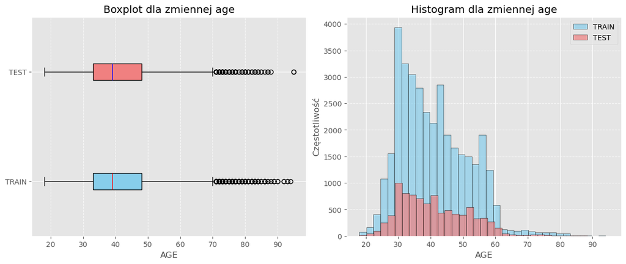

```python
fig, axes = plt.subplots(1, 2, figsize=(12, 5), frameon=True, constrained_layout=True)
rysuj_boxplot(X_train,X_test,tytul="Boxplot dla zmiennej age",kolumna="age",ax=axes[0])
rysuj_histogram(X_train,X_test,"age",tytul="Histogram dla zmiennej age",liczba_bin=35,ax=axes[1])
```

Zarówno na wykresie po lewej stronie jak i na histogramie obserwujemy, że dane nie są rozłożone równomiernie.  
Najwięcej danych znajduje się w przedziale [33: 50) ( co zauważyliśmy już analizując statystyki opisowe ) .  
Przy czym, najliczniejszą grupę stanowią osoby w wieku około 30 lat.

Na histogramie widzimy znaczący spadek liczby osób powyżej 60 roku życia, co może wpływać na jakość modelu dla tej grupy wiekowej.  
Natomiast z boxplotu możemy odczytać, że osoby w wieku 70 lat i starsze występują na tyle rzadko, że traktowane są jako obserwacje odstające.

Ponadto dla obu zbiorów struktura danych jest taka sama.

### Zależność ze zmienną objaśnianą

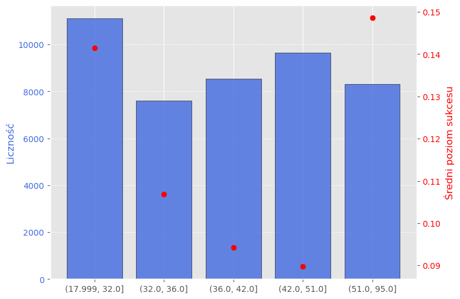

```python
wykres_zaleznosci(X_train,"age",size=40)
```

## Job – rodzaj pracy

Typ zatrudnienia może determinować poziom dochodów oraz stabilność finansową klienta.  
Na przykład osoby pracujące w zawodach związanych z finansami czy zarządzaniem mogą częściej decydować się na inwestycje.  
Natomiast osoby bezrobotne lub studenci mogą nie być docelową grupą kampanii.

### Rozkład danych

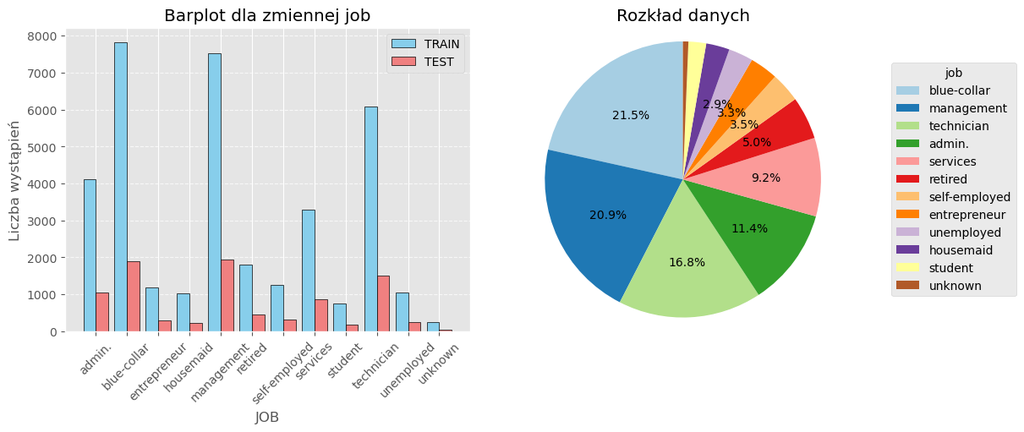

```python
fig, axes = plt.subplots(1, 2, figsize=(12, 5), frameon=True, constrained_layout=True)
rysuj_barplot(X_train,X_test,"job",tytul="Barplot dla zmiennej job",ax=axes[0])
rysuj_kolowy(dane, 'job',ax=axes[1])
```

Obserwujemy, że w przypadku zatrudnienia dane również nie są rozłożone równomiernie.  
Najliczniejszą grupę stanowią osoby pracujące fizycznie oraz na stanowiskach zarządczych i jest to około 21% badanych.  
Drugą co do liczebności jest grupa techników, którzy stanowią około 16%.  
Natomiast najmniej osób obserwujemy w grupie studentów, pokojówek oraz o nieznanym stanowisku. ( mniej niż 3 %)

Proporcje zgodnie z oczekiwaniami są zachowane dla obu zestawu danych.

### Zależność ze zmienną objaśnianą

Do analizy tej części użyjemy następujących oznaczeń:

- admin. - 0
- blue-collar - 1
- entrepreneur - 2
- housemaid - 3
- management - 4
- retired - 5
- self-employed - 6
- services - 7
- student - 8
- technician - 9
- unemployed -10
- unknown - 11

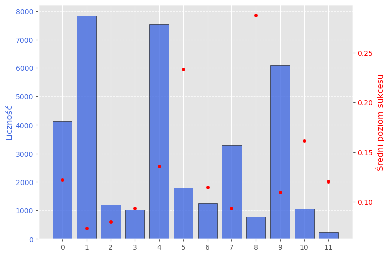

```python
wykres_zaleznosci(X_train,"job")
```

- Najwyższy poziom sukcesu obserwujemy wśród studentów oraz emerytów. Może to wynikać z mniejszej liczebności tych grup, co ułatwia osiąganie lepszych wyników.  
  Studenci, być może ze względu na atrakcyjne promocje, mogą być bardziej otwarci na oferty bankowe, podczas gdy emeryci, skłonni do ostrożniejszego zarządzania swoimi finansami, chętniej lokują swoje oszczędności.
- Stosunkowo wysoki poziom sukcesu odnotowano również wśród osób bezrobotnych.  
  Część z nich może korzystać z oszczędności lub innych form wsparcia finansowego, co wpływa na ich decyzje dotyczące lokat.
- Z kolei najniższy poziom sukcesu zauważalny jest wśród pracowników fizycznych.  
  Przyczyną może być znacząca liczebność tej grupy, co może utrudniać osiąganie wysokich wyników w porównaniu do mniejszych, bardziej zróżnicowanych grup.  
  Jednak może to rónież świadczyć o tym, że osoby pracujące fizycznie nie są zainteresowane lokatami.

## Marital – stan cywilny

Stan cywilny może wpływać na decyzje finansowe – np. osoby zamężne/żonate mogą mieć inne priorytety oszczędnościowe niż osoby samotne.

### Rozkład danych

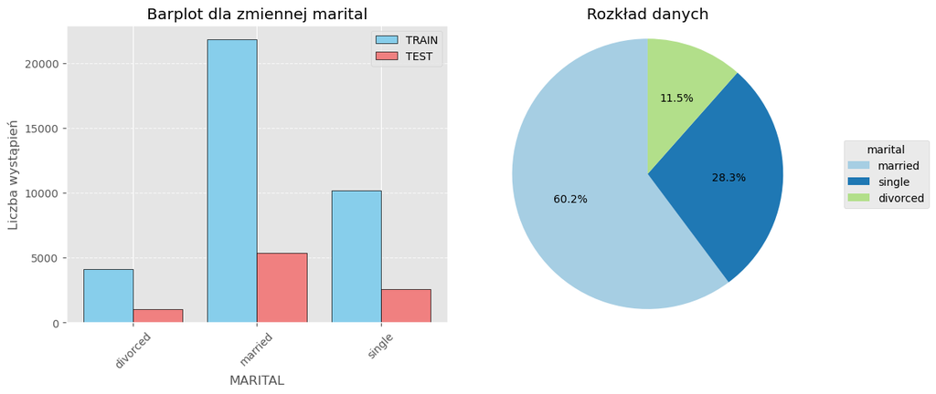

```python
fig, axes = plt.subplots(1, 2, figsize=(12, 5), frameon=True, constrained_layout=True)
rysuj_barplot(X_train,X_test,"marital",tytul="Barplot dla zmiennej marital",ax=axes[0])
rysuj_kolowy(dane, 'marital',ax=axes[1])
```

Obserwowana jest zdecydowana przewaga osób w związkach małżeńskich, stanowią ponad połowę klientów kampanii- jest to zjawisko, którego mogliśmy się spodziewać wcześniej analizując wiek klientów ( najwięcej osób w średnim wieku ).

Drudzy są single, którzy stanowią kolejną znaczącą grupę klientów.  
Choć jest ich mniej niż osób w związkach małżeńskich, to nadal reprezentują istotną część naszych danych.

Najmniej liczną grupę stanowią osoby rozwiedzione/wdowcy.

W zbiorze testowym widoczne są takie same propocje.

### Zależność ze zmienną objaśnianą

Do analizy tej części użyjemy następujących oznaczeń:

- divorced - 0
- married - 1
- single - 2

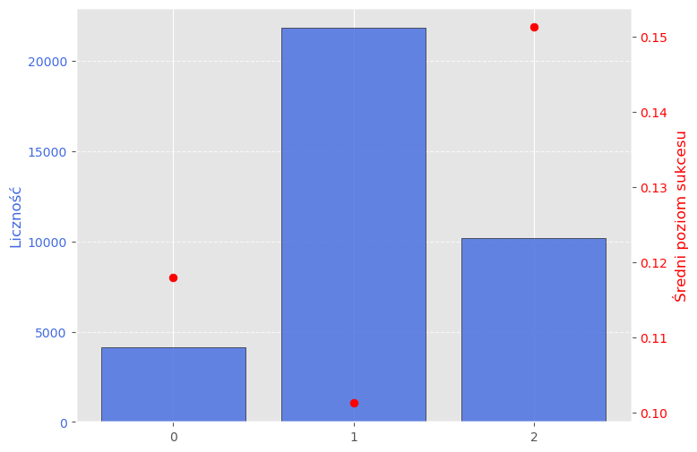

```python
wykres_zaleznosci(X_train,"marital",size=40)
```

- Z wykresu wynika, że to osoby samotne najczęściej decydują się na zakładanie lokat.  
  Może to wynikać z chęci oszczędzania na rozwój, podróże lub z mniejszej liczby bieżących wydatków.  
  Dodatkowo, w tej grupie prawdopodobnie znajdują się osoby młodsze oraz studenci, wśród których zauważyliśmy już podobną tendencję.
- Z kolei wśród najliczniejszej grupy obserwujemy jedynie 10$\%$ osób decydujących się na lokaty.  
  Może to być spowodowane dużą liczebnością tej grupy, jej zróżnicowanym wiekiem oraz sytuacją zawodową jej członków.

## Education – poziom wykształcenia

Wykształcenie często związane jest z dochodami i wiedzą finansową.  
Osoby z wyższym wykształceniem mogą lepiej rozumieć zalety lokat terminowych i częściej decydować się na ich subskrypcję.

### Rozkład danych

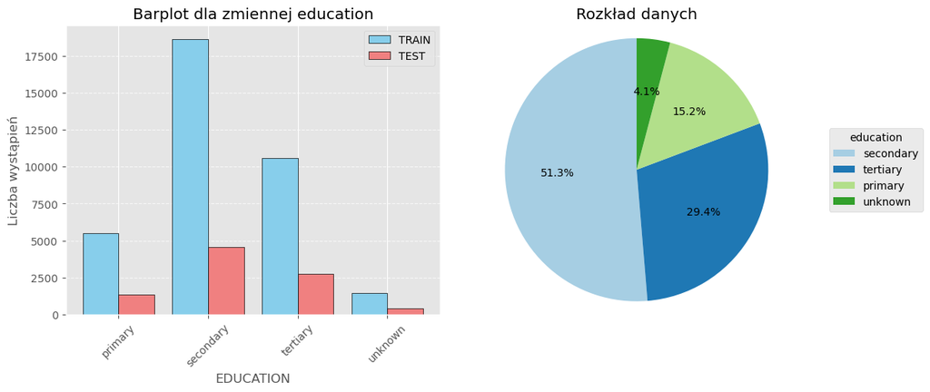

```python
fig, axes = plt.subplots(1, 2, figsize=(12, 5), frameon=True, constrained_layout=True)
rysuj_barplot(X_train,X_test,"education",tytul="Barplot dla zmiennej education",ax=axes[0])
rysuj_kolowy(dane, 'education',ax=axes[1])
```

Widzimy, że wśród klientów kampanii poziom wykształcenia jest dość zróżnicowany.

Najwięcej osób ukończyło szkołę średnią – stanowią oni ponad połowę wszystkich klientów. Sporą grupę stanowią również osoby z wykształceniem podstawowym.  
Można było się tego spodziewać, biorąc pod uwagę liczebność osób pracujących fizycznie, studentów oraz przedstawicieli zawodów, w których formalne wykształcenie nie jest wymagane.

Drugą co do wielkości grupę stanowią osoby po studiach, co pokrywa się z liczbą osób zatrudnionych na stanowiskach zarządczych, technicznych i specjalistycznych.

Najmniej liczna grupa to osoby, których poziom wykształcenia nie jest znany.  
Jest to korzystne z punktu widzenia konstrukcji modelu, ponieważ mniejsza ilość brakujących danych zwiększa jego dokładność i wiarygodność.

Podobnie jak wcześniej w zbiorze treningowym propocje są zachowane.

### Zależność ze zmienną objaśnianą

W tej części posłużymy się oznaczeniami:

- primary - 0
- secondary - 1
- tertiary - 2
- unknown - 3

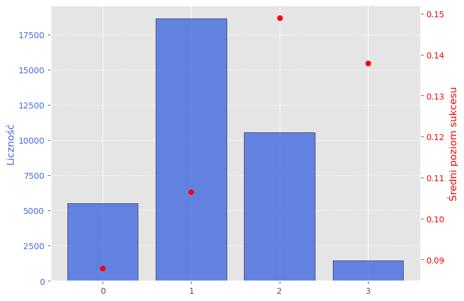

```python
wykres_zaleznosci(X_train,"education",size=40)
```

## Default – czy klient ma zaległości w spłacie kredytu?

Informacja o zaległościach w spłacie kredytu wskazuje na poziom wiarygodności finansowej klienta.  
Osoby z negatywną historią kredytową mogą być mniej skłonne do oszczędzania lub mogą nie kwalifikować się do pewnych ofert bankowych.

### Rozkład danych

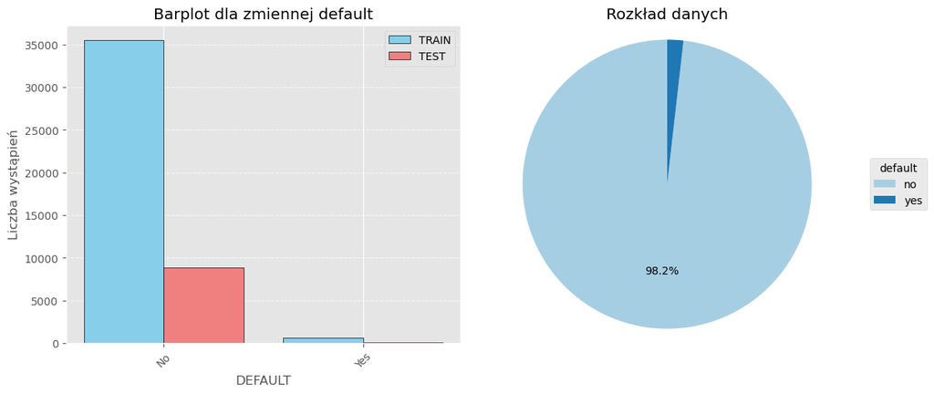

```python
fig, axes = plt.subplots(1, 2, figsize=(12, 5), frameon=True, constrained_layout=True)
rysuj_barplot(X_train,X_test,"default",tytul="Barplot dla zmiennej default",ax=axes[0])
rysuj_kolowy(dane,"default",ax=axes[1])
```

Zdecydowaną większość klientów stanowią osoby bez negatywnej historii kredytowej, co jest pozytywnym sygnałem dla kampanii.  
Oznacza to, że potencjalni klienci są bardziej wiarygodni finansowo, co może zwiększyć skuteczność oferty.

### Zależność ze zmienną objaśnianą

Podobnie jak wcześniej wprowadzimy oznaczenia:

- No - 0
- Yes - 1

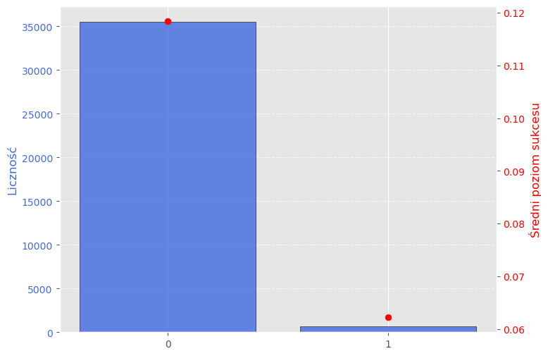

```python
wykres_zaleznosci(X_train,'default',size=40)
```

Zgodnie z przypuszczeniami osoby bez negatywnej historii kredytowej częściej decydują się na subskrypcje lokat.

## Balance – średnie roczne saldo na koncie klienta (w euro)

Średnie roczne saldo na koncie odzwierciedla sytuację finansową klienta.  
Osoby z wyższym saldem mogą mieć większe możliwości oszczędzania, podczas gdy osoby z niskim lub ujemnym saldem mogą nie być zainteresowane lokatami.

### Rozkład danych

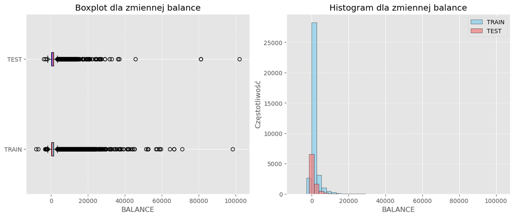

```python
fig, axes = plt.subplots(1, 2, figsize=(12, 5), frameon=True, constrained_layout=True)
rysuj_boxplot(X_train,X_test,"balance",tytul="Boxplot dla zmiennej balance",ax=axes[0])
rysuj_histogram(X_train,X_test,"balance",tytul="Histogram dla zmiennej balance",liczba_bin=40,ax=axes[1])
```

Pierwszą rzeczą, którą możemy zauważyć, jest bardzo duża liczba obserwacji odstających, widoczna na lewym wykresie.  
Zarówno osoby z ujemnym rocznym saldem, jak i te z saldem większym niż 10 tysięcy euro stanowią zdecydowaną rzadkość – szczególnie w przypadku salda przekraczającego 60 tysięcy euro.

Wpływ tych obserwacji jest na tyle silny, że zniekształca rozkład widoczny na histogramie.  
Jednak wcześniejsza analiza statystyk opisowych pokazuje, że zdecydowana większość klientów nie przekracza średniego salda wynoszącego 1500 euro, a średnia oscyluje wokół 1360 euro.

Ogólny charakter w obu zbiorach danych jest podobny.

### Zależność ze zmienną objaśnianą

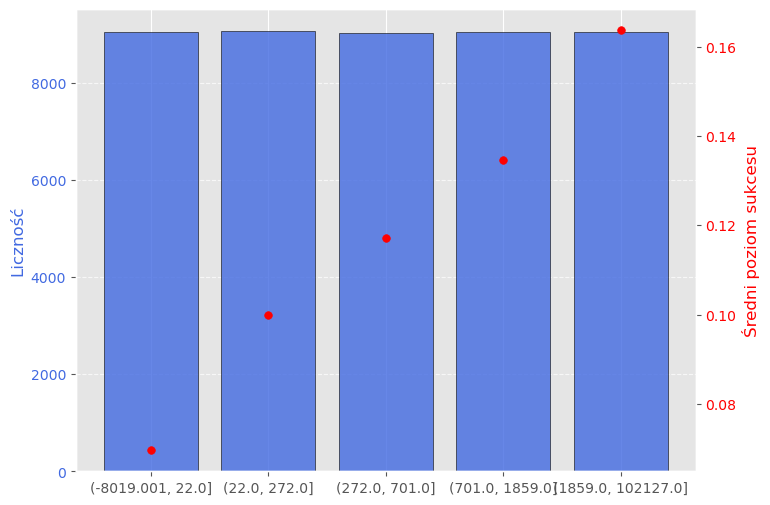

```python
wykres_zaleznosci(X_train,"balance",size=30)
```

Zgodnie z oczekiwaniami obserwujemy tendencję wzrostową – im wyższe saldo, tym większa skłonność do zakładania lokat.

Najrzadziej decydują się na nie osoby zadłużone oraz te o najniższych dochodach.  
Wraz ze wzrostem salda sukces kampanii staje się coraz bardziej prawdopodobny, co sugeruje, że stabilność finansowa sprzyja podejmowaniu decyzji o oszczędzaniu.

## Housing – czy klient ma kredyt hipoteczny?

Posiadanie kredytu hipotecznego może wskazywać na większe obciążenie finansowe klienta, co może wpływać na jego skłonność do inwestowania w dodatkowe produkty bankowe.

### Rozkład danych

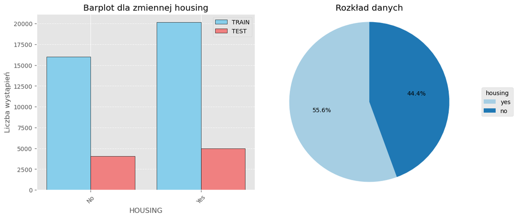

```python
fig, axes = plt.subplots(1, 2, figsize=(12, 5), frameon=True, constrained_layout=True)
rysuj_barplot(X_train,X_test,"housing",tytul="Barplot dla zmiennej housing",ax=axes[0])
rysuj_kolowy(dane,"housing",ax=axes[1])
```

### Zależność ze zmienną objaśnianą

Podobnie jak wcześniej wprowadzamy oznaczenia:

- No - 0
- Yes - 1

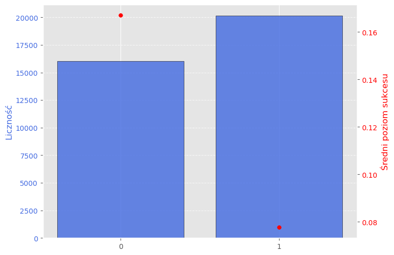

```python
wykres_zaleznosci(X_train,"housing",size=30)
```

Zdecydowaną większość osób decydujących się na lokaty stanowią klienci, którzy nie posiadają kredytu hipotecznego.  
Może to wynikać z faktu, że w tej grupie znajdują się osoby młodsze, niezamężne oraz studenci, którzy jeszcze nie zdecydowali się na zakup nieruchomości, a także osoby starsze, które już spłaciły swoje zobowiązania.

Brak obciążenia kredytem hipotecznym może oznaczać większą elastyczność finansową i większe możliwości oszczędzania, co sprzyja decyzji o ulokowaniu środków w lokatach bankowych.

## Loan – czy klient ma kredyt gotówkowy?

Podobnie jak w przypadku kredytu hipotecznego, posiadanie kredytu gotówkowego może sugerować, że klient jest już obciążony finansowo i może być mniej skłonny do założenia lokaty.

### Rozkład danych

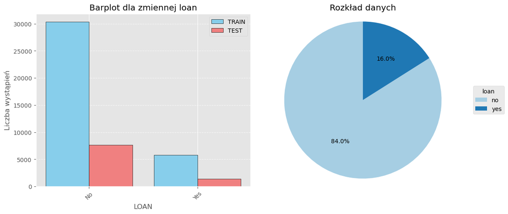

```python
fig, axes = plt.subplots(1, 2, figsize=(12, 5), frameon=True, constrained_layout=True)
rysuj_barplot(X_train,X_test,"loan",tytul="Barplot dla zmiennej loan",ax=axes[0])
rysuj_kolowy(dane,'loan',ax=axes[1])
```

W przypadku kredytu gotówkowego w obu zbiorach danych obserwujemy zdecydowaną przewagę osób nieobciążonych tego typu zobowiązaniem.  
Może to być związane z wcześniejszymi obserwacjami dotyczącymi wieku, rodzaju zatrudnienia, wykształcenia oraz poziomu zarobków klientów.

Osoby młodsze, studenci oraz osoby o niższych dochodach mogą unikać dodatkowych zobowiązań finansowych, natomiast osoby w średnim wieku i z wyższym wykształceniem, które częściej zajmują stanowiska zarządcze lub techniczne, mogą już mieć większą stabilność finansową i nie potrzebować kredytu gotówkowego.

Z kolei osoby starsze, które wcześniej mogły korzystać z kredytów, mogły już je spłacić, co również wpływa na przewagę grupy osób bez tego rodzaju zobowiązań.

### Zależność ze zmienną objaśnianą

Tak jak w przypadku poprzednich zmiennych binarnych, wprowadzamy oznaczenia:

- No - 0
- Yes - 1

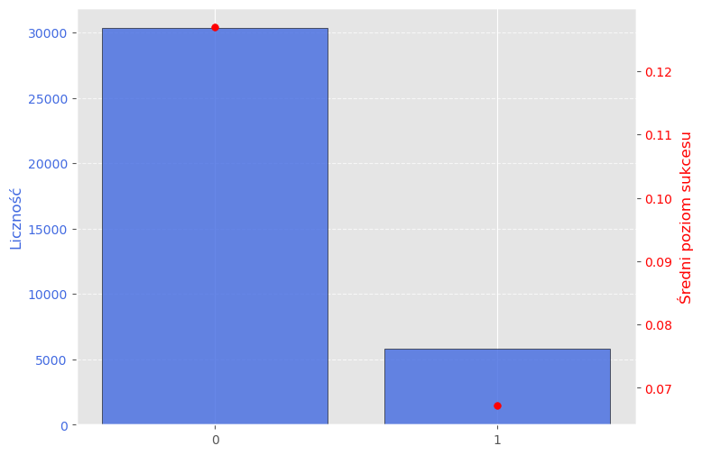

```python
wykres_zaleznosci(X_train,"loan",size=30)
```

Podobnie jak w przypadku kredytu hipotecznego, obserwujemy wyższą skłonność do subskrypcji lokat wśród osób nieobciążonych dodatkowymi zobowiązaniami.  
Może to wynikać z większej swobody finansowej oraz mniejszej potrzeby alokowania środków na spłatę rat kredytowych.

Warto jednak zauważyć, że mimo tej tendencji, odsetek sukcesu w tej grupie nie jest wysoki.  
Może to być efektem dużej liczebności oraz wewnętrznego zróżnicowania tej grupy

## Wnioski

Osoby o stabilnej sytuacji finansowej, wyższym wykształceniu oraz bez obciążeń kredytowych są bardziej skłonne do zakładania lokat.  
Najwyższy poziom sukcesu obserwujemy wśród studentów, emerytów i osób z wyższym saldem, co sugeruje, że zarówno młodzi, poszukujący korzystnych ofert, jak i starsi, świadomi potrzeby oszczędzania, są kluczowymi grupami docelowymi.  
Natomiast osoby w średnim wieku, pracujące fizycznie lub obciążone kredytami, rzadziej decydują się na lokaty, co może wynikać z ograniczonej elastyczności finansowej i innych priorytetów wydatkowych.

# Informacje o ostatnim kontakcie w bieżącej kampanii

## Contact - typ komunikacji

Rodzaj kanału kontaktu (telefon stacjonarny vs. komórkowy) może mieć wpływ na skuteczność kampanii.  
Kontakt przez telefon komórkowy może być wygodniejszy dla klientów, ale też bardziej podatny na szybkie odrzucenie połączenia.

### Rozkład danych

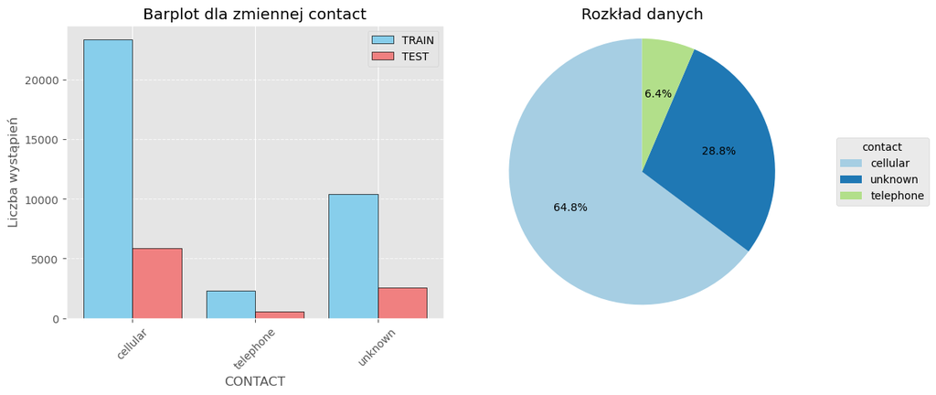

```python
fig, axes = plt.subplots(1, 2, figsize=(12, 5), frameon=True, constrained_layout=True)
rysuj_barplot(X_train,X_test,"contact",tytul="Barplot dla zmiennej contact",ax=axes[0])
rysuj_kolowy(dane,'contact',ax=axes[1])
```

Istotnie dużą grupę stanowią osoby, z którymi kontakt odbywał się przez telefon komórkowy ( prawie 65 $\%$), natomiast najmniejszy odsetek połączeń został wykonany na telefon stacjonaryny.  
Wynika to prawdopodobnie z faktu, że coraz mniej osób korzysta z formy komunikacji jaką jest telefon stacjonary, a coraz więcej osób ( w tym osoby starsze ) są w posiadaniu telefonu komórkowego.  
Z tego względu jest to bardziej uniwersalna metoda kontaktu, jak również zapewnia wygodę - ludzie zazwyczaj nie rozstają się ze swoim telefonem komórkowym.

Warto również zwrócić uwagę na znaczącą liczbę osób, w przypadku których typ komunikacji nie jest znany, ponieważ łączy w sobie osoby z obu wyżej wymienionych grup. Może to oznaczać, że kontakt nie został odnotowany lub prowadzono go innymi kanałami.

### Zależność ze zmienną objaśnianą

W tym przypadku opis oznaczeń jest następujący:

- cellular - 0
- telephone - 1
- unknown - 2

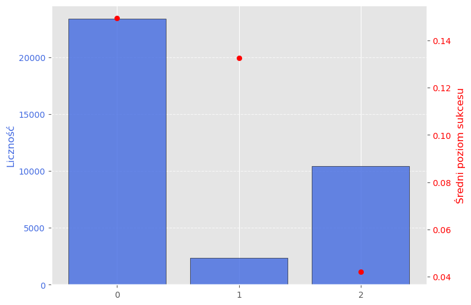

```python
wykres_zaleznosci(X_train,"contact",size=35)
```

- Najwyższy poziom sukcesu (15$\%$) przypada na najliczniejszą grupę, co sugeruje, że kontakt przez telefon komórkowy jest najskuteczniejszą metodą dotarcia do klientów.
- Kontakt przez telefon stacjonarny również może być efektywny ( odsetek sukcesu wynosi około 13 $\%$ ), ale ze względu na niewielką liczbę osób korzystających z tej formy komunikacji jego znaczenie jest ograniczone.
- Niska skuteczność w grupie o nieznanym rodzaju kontaktu wskazuje, że brak precyzyjnych danych na temat metody komunikacji może negatywnie wpływać na efektywność kampanii.

## Day - dzień ostatniego kontaktu w miesiącu

Dzień miesiąca, w którym nastąpił kontakt, może mieć wpływ na decyzję klienta.  
Na przykład rozmowy na początku miesiąca mogą trafiać na klientów, którzy właśnie otrzymali wypłatę i są bardziej skłonni do inwestowania.

### Rozkład danych

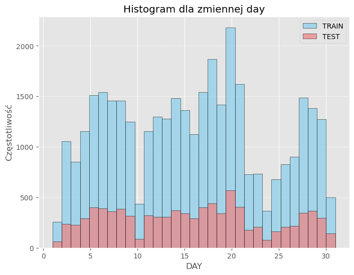

```python
rysuj_histogram(X_train,X_test,"day",tytul="Histogram dla zmiennej day",liczba_bin=31)
```

Rozkład danych w obu zbiorach wskazuje, że najwięcej kontaktów odbyło się w okolicach środka miesiąca, szczególnie około 20. dnia.  
Natomiast najmniej połączeń wykonywanych było na początku oraz na końcu miesiąca.

Może to wynikać z organizacji pracy zespołu sprzedażowego, który intensyfikuje działania w środkowej części miesiąca, a także z większej dostępności klientów w tym okresie.  
Warto również zauważyć, że występują pojedyncze dni w środku miesiąca, w których liczba kontaktów jest znacząco niższa, co może być efektem dni wolnych, wewnętrznych zmian organizacyjnych lub specyficznych strategii działania.

### Zależność ze zmienną objaśnianą

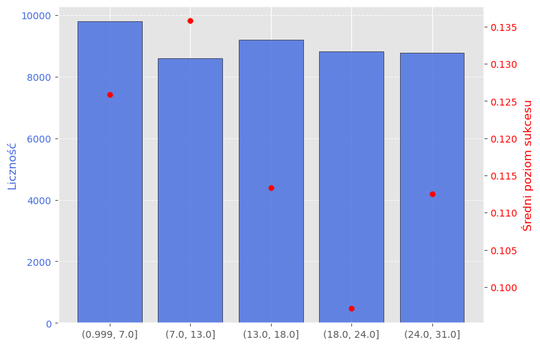

```python
wykres_zaleznosci(X_train,"day",size=30)
```

- Najlepszym okresem na kontakt był przedział 7–13 dnia miesiąca ( ponad 13.5 $\%$ ) skuteczności, co może być związane z wpływem wynagrodzeń i większą skłonnością do oszczędzania.
- Najmniej skuteczny okres to dni 18–24 ( poniżej 10 $\%$ ), co może wynikać z mniejszej dostępności środków po opłaceniu zobowiązań.
- Początek miesiąca (0–7) również wykazuje dobrą skuteczność, warto więc w tym czasie prowadzić intensywne działania.
- Pod koniec miesiąca (24–31) skuteczność nieco wzrasta, co może sugerować, że część klientów ponownie analizuje swoje finanse przed nowym miesiącem.

## Month - miesiąc ostatniego kontaktu

Sezonowość może mieć wpływ na liczbę kontaktów – na przykład latem działania marketingowe mogą być bardziej skuteczne, a pod koniec roku spadek aktywności może być związany z okresem świątecznym i mniejszą skłonnością do podejmowania decyzji finansowych.

### Rozkład danych

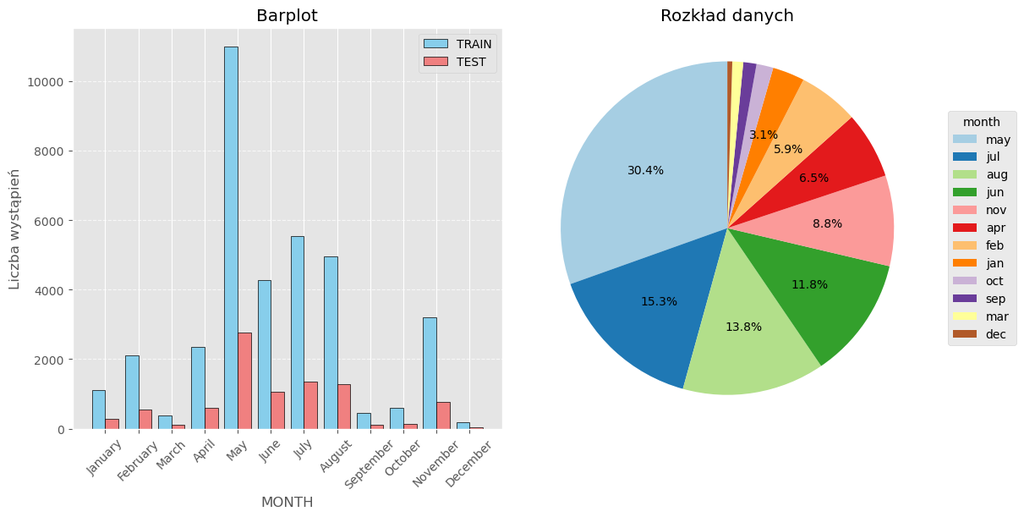

```python
fig, axes = plt.subplots(1, 2, figsize=(12, 6), frameon=True, constrained_layout=True)
rysuj_barplot(X_train,X_test,'month',ax=axes[0])
rysuj_kolowy(dane,'month',ax=axes[1])
```

Pierwszym spostrzeżeniem jest znacząca różnica w liczbie kontaktów w poszczególnych miesiącach.  
Najwięcej osób skontaktowano w maju ( aż 30 $\%$ ), a najmniej w grudniu, co może wynikać z zakończenia roku i świątecznego okresu.  
Zauważalny jest także wzrost liczby kontaktów w okresie wakacyjnym, co sugeruje większą aktywność marketingową latem.  
Takie zmiany mogą być związane z cyklicznością kampanii lub sezonowymi preferencjami klientów.

### Zależność ze zmienną objaśnianą

Do analizy tego wykresu ponownie użyjemy oznaczeń, które w tym przypadku niestety nie będą zbyt intuicyjne, więc trzeba na nie zwroćić szczególną uwagę.

#### Opis oznaczeń

- 0 - April
- 1 - August
- 2 - December
- 3 - February
- 4 - January
- 5 - July
- 6 - June
- 7 - March
- 8 - May
- 9 - November
- 10 - October
- 11 - September

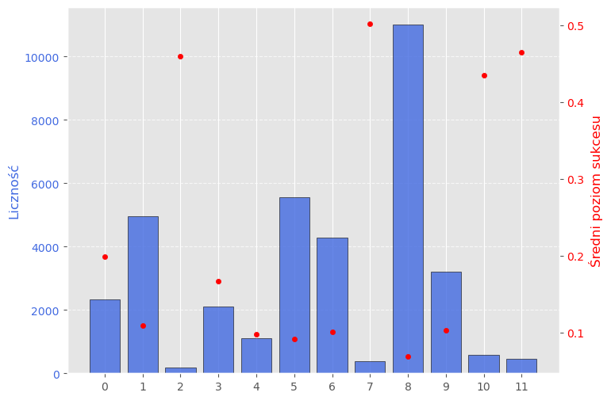

```python
wykres_zaleznosci(X_train,'month')
```

- Najbardziej skutecznymi miesiącami na kontakt okazały się marzec, wrzesień, październik oraz grudzień, osiągając około 50$\%$ skuteczności wśród osób, z którymi nawiązano kontakt. Może to wynikać z faktu, że te grupy są najmniejsze, co sprawia, że mogą być bardziej jednorodne pod względem cech, które wpłynęły na ich decyzje.
- Najmniejszy poziom sukcesu występuje w przypadku osób, z którymi kontaktowano się w Maju (poniżej 10$\%$).  
  Może to być efektem większej liczebności tej grupy, co prowadzi do jej większego zróżnicowania
- Zauważalny jest również wyższy odsetek pozytywnych decyzji (około 20$\%$) w Lutym oraz w Kwietniu.  
  Może to wskazywać na specyficzne czynniki sezonowe, takie jak planowanie finansowe po Nowym Roku, które wpływają na decyzje klientów w tych miesiącach.
- Dla pozostałych miesięcy, w tym tych z większą liczebnością grup, odsetek wynosi około 10$\%$

## Duration - czas trwania ostatniego kontaktu (w sekundach)

Długość rozmowy może być kluczowym wskaźnikiem zaangażowania klienta.  
Krótkie rozmowy (np. 0 sekund) mogą oznaczać szybkie odrzucenie połączenia, podczas gdy dłuższe rozmowy mogą wskazywać na zainteresowanie ofertą.

### Rozkład danych

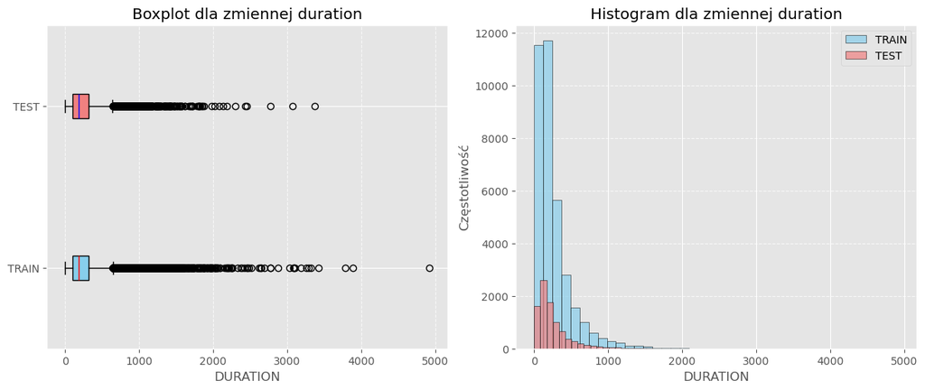

```python
fig, axes = plt.subplots(1, 2, figsize=(12, 5), frameon=True, constrained_layout=True)
rysuj_boxplot(X_train,X_test,"duration",tytul="Boxplot dla zmiennej duration",ax=axes[0])
rysuj_histogram(X_train,X_test,"duration",tytul="Histogram dla zmiennej duration",liczba_bin=40,ax=axes[1])
```

Podobnie jak w przypadku zmiennej `balance` wpływ tych obserwacji zniekształca rozkład widoczny na histogramie.  
Jednak zarówno na boxplocie, jak i na histogramie możemy zauważyć, że większość danych znajduje się poniżej 1000 sekund ( 16 minut ).

Z wcześniejszej analizy statystyk opisowych wiemy, że średni czas rozmowy wyniósł około 4 minut, a większość rozmów nie przekracza 5 minut.

Ogólny charakter w obu zbiorach danych jest podobny.

### Zależność ze zmienną objaśnianą

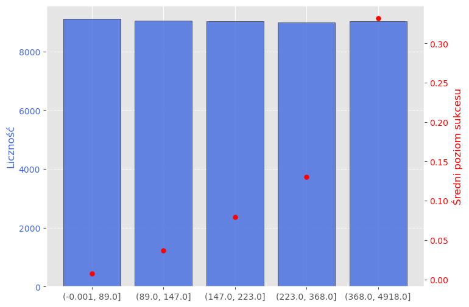

```python
wykres_zaleznosci(X_train,"duration",size=30)
```

Zgodnie z oczekiwaniami obserwujemy pozytywną zależność między czasem trwania ostatniego kontaktu a skutecznością kampanii – dłuższa rozmowa zwiększa prawdopodobieństwo założenia lokaty.

Najkrótsze rozmowy najczęściej kończą się brakiem zainteresowania ofertą, co może wynikać z szybkiego odrzucenia propozycji przez klienta.  
Z kolei dłuższe interakcje sugerują większe zaangażowanie rozmówcy, co sprzyja skuteczności kampanii.

## Wnioski

Skuteczność kampanii zależy od kilku kluczowych czynników.  
Kontakt telefoniczny przez komórkę jest najskuteczniejszy, a najlepszy czas na rozmowy to okres 7–13 dnia miesiąca.  
Wyższa skuteczność występuje w miesiącach takich jak marzec, wrzesień i grudzień.  
Dłuższe rozmowy sprzyjają pozytywnym decyzjom, co wskazuje na większe zaangażowanie klientów. Optymalizacja tych zmiennych może poprawić efektywność kampanii.

# Inne zmienne

## Campaign - liczba kontaktów wykonanych w tej kampanii dla danego klienta

Zmniejszająca się skuteczność kolejnych prób kontaktu może sugerować, że wielokrotne telefony do tego samego klienta mogą prowadzić do zniechęcenia i spadku efektywności kampanii.

### Rozkład danych

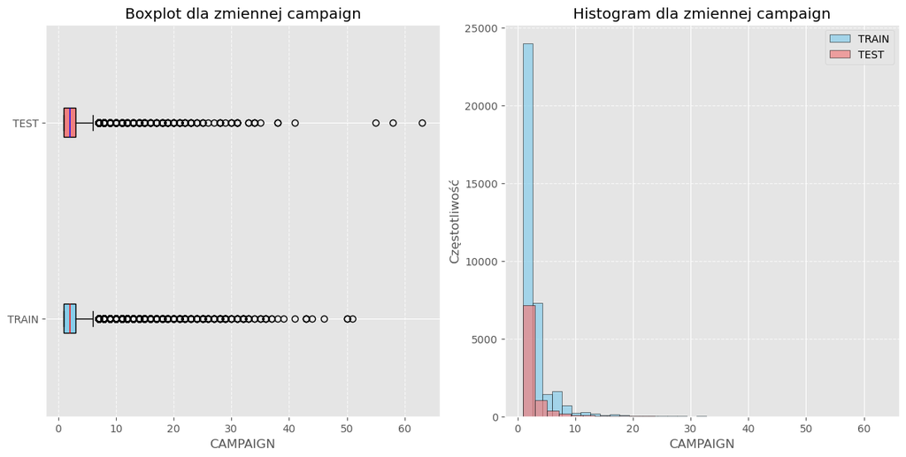

```python
fig, axes = plt.subplots(1, 2, figsize=(12, 6), frameon=True, constrained_layout=True)
rysuj_boxplot(X_train,X_test,"campaign",tytul="Boxplot dla zmiennej campaign",ax=axes[0])
rysuj_histogram(X_train,X_test,"campaign",tytul="Histogram dla zmiennej campaign",liczba_bin=30,ax=axes[1])
```

W przypadku tej zmiennej ponownie obserwujemy, że spora część obserwacji została zakwalifikowana jako odstające.  
Wynika to z faktu, że sporą część klientów stanowią osoby, z którymi kontaktowano się zaledwie kilka razy - co możemy zauważyć na histogramie.

Osoby, z którymi kontaktowano się więcej niż 7 razy stanowią rzadkość - szczególnie powyżej 40 razy.

Zarówno na boxplocie, jak i na histogramie możemy zauważyć, że większość danych znajduje się poniżej progu 10 rozmów.

Z wcześniejszej analizy statystyk opisowych wiemy, że z większością klientów nie kontaktowano się więcej niż 3 razy.

### Zależność ze zmienną objaśnianą

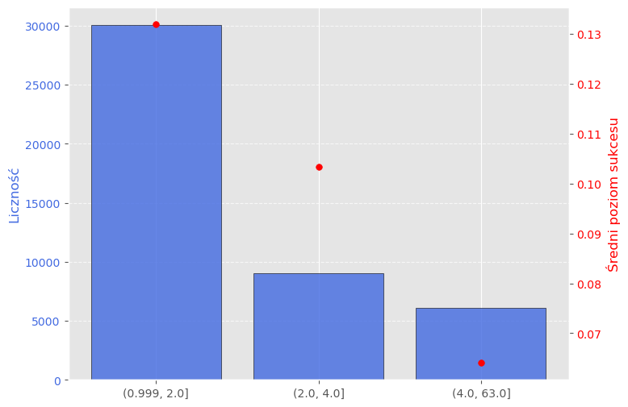

```python
wykres_zaleznosci(X_train,"campaign",size=30)
```

Możemy zauważyć pewną tendencję spadkową.

- Największa skuteczność kampanii jest w grupie osób, z którymi kontakowano się zaledwei raz lub dwa razy - około 13 $\%$.
- Najniższa skuteczność dotyczy natomiast grupy, w której liczba kontaktów była znacznie większa.  
  Może to sugerować, że nadmierna liczba interakcji może prowadzić do zniechęcenia lub zmniejszonej skuteczności kampanii.

## Pdays - liczba dni od ostatniego kontaktu klienta w poprzedniej kampanii

Klienci, którzy mieli dłuższą przerwę od ostatniego kontaktu, mogą być mniej skłonni do subskrypcji niż ci, którzy byli niedawno angażowani.

### Rozkład danych

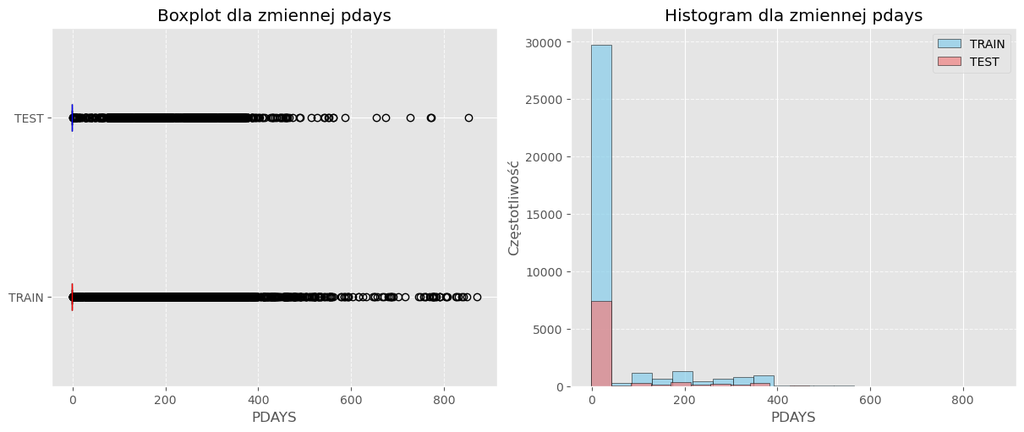

```python
fig, axes = plt.subplots(1, 2, figsize=(12, 5), frameon=True, constrained_layout=True)
rysuj_boxplot(X_train,X_test,"pdays",tytul="Boxplot dla zmiennej pdays",ax=axes[0])
rysuj_histogram(X_train,X_test,"pdays",tytul="Histogram dla zmiennej pdays",liczba_bin=20,ax=axes[1])
```

### Zależność ze zmienną objaśnianą

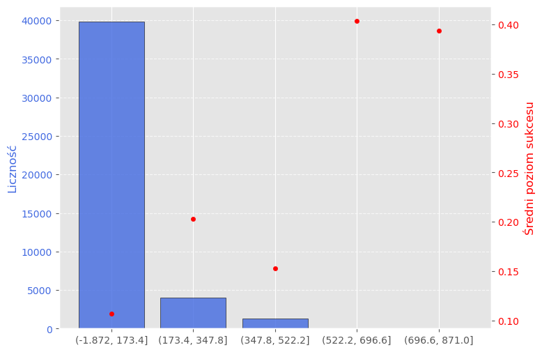

```python
wykres_zaleznosci(X_train,'pdays')
```

- Największa grupa klientów (około 40 tysięcy) mieści się w przedziale[-1,173). Mimo liczebności tej grupy, wskaźnik sukcesu wynosi jedynie 10,5%. Większość tych osób nie miała wcześniejszego kontaktu w ramach kampanii, co może tłumaczyć ich mniejsze zainteresowanie ofertą.
- Druga grupa jest znacznie mniejsza (ok. 5 tysięcy klientów), jednak wskaźnik sukcesu przekracza 20%.  
  Wynik ten sugeruje, że klienci, którzy mieli wcześniejszy kontakt, są bardziej skłonni do podjęcia decyzji o lokacie.
- Dwie ostatnie grupy charakteryzują się najwyższymi wskaźnikami sukcesu (około 40%), mimo że ich liczebność jest niewidoczna na wykresie. Może to wskazywać, że dla pewnych klientów ponowny kontakt po bardzo długim czasie jest skuteczniejszy.

## Previous – liczba kontaktów wykonanych przed tą kampanią dla danego klienta

Może wskazywać, jak często klient był angażowany w kampanie marketingowe w przeszłości. Jeśli klient wielokrotnie otrzymywał oferty, ale nigdy ich nie zaakceptował, może to sugerować, że nie jest zainteresowany.

### Rozkład danych

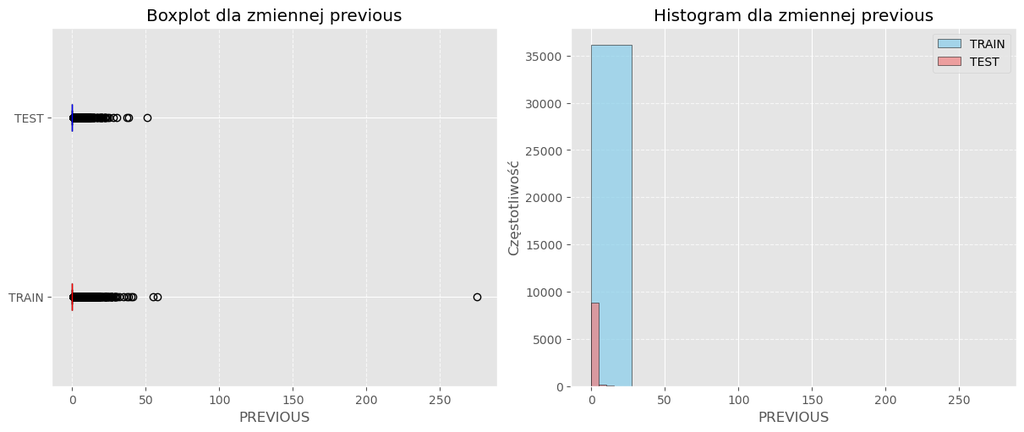

```python
fig, axes = plt.subplots(1, 2, figsize=(12, 5), frameon=True, constrained_layout=True)
rysuj_boxplot(X_train,X_test,"previous",tytul="Boxplot dla zmiennej previous",ax=axes[0])
rysuj_histogram(X_train,X_test,"previous",tytul="Histogram dla zmiennej previous",liczba_bin=10,ax=axes[1])
```

### Zależność ze zmienną objaśnianą

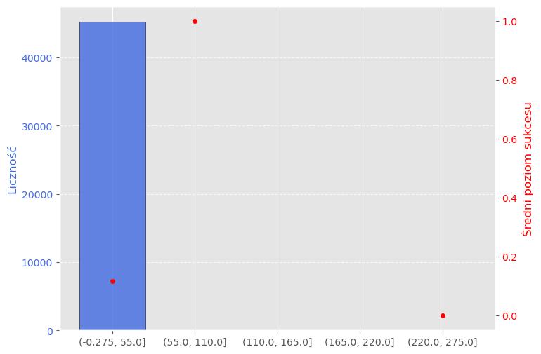

```python
wykres_zaleznosci(X_train,"previous")
```

Zmienna `previous` wydaje się mieć ograniczoną wartość informacyjną, ponieważ niemal wszystkie obserwacje mieszczą się w jednym przedziale ( w którym większość to osoby, z którymi wcześniej nie było kontaktu), a średni wskaźnik sukcesu wynosi niespełna 20%.

Warto jednak zwrócić uwagę na skrajne przypadki:

- W jednym z przedziałów wskaźnik sukcesu wynosi 100%, co sugeruje, że dotyczy on niewielkiej grupy klientów, którzy byli wcześniej wielokrotnie kontaktowani i ponownie zdecydowali się na subskrypcję.
- Z kolei w ostatnim przedziale wskaźnik sukcesu wynosi 0% – odpowiada on pojedynczej obserwacji, co oznacza, że mimo bardzo częstego kontaktu ta osoba nie zdecydowała się na ofertę.

Taki rozkład wskazuje na silną asymetrię i sugeruje, że zmienna ta może mieć ograniczoną wartość predykcyjną w kontekście skuteczności kampanii.

## Poutcome – wynik poprzedniej kampanii marketingowej

Jeśli klient pozytywnie zareagował na wcześniejszą kampanię (poutcome = success), istnieje większe prawdopodobieństwo, że ponownie zdecyduje się na subskrypcję lokaty.

### Rozkład danych

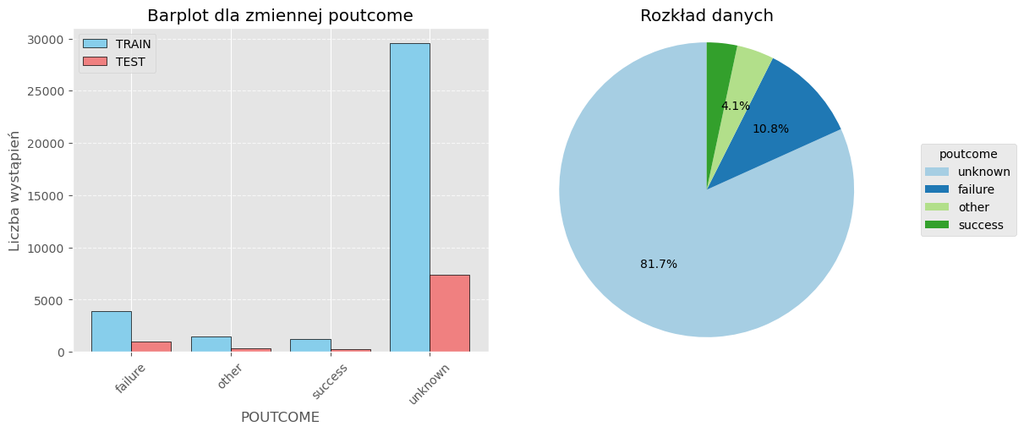

```python
fig, axes = plt.subplots(1, 2, figsize=(12, 5), frameon=True, constrained_layout=True)
rysuj_barplot(X_train,X_test,"poutcome",tytul="Barplot dla zmiennej poutcome",ax=axes[0])
rysuj_kolowy(dane,'poutcome',min_pct=3.4,ax=axes[1])
```

Większość stanowią osoby, dla których wynik poprzedniej kampanii jest nieznany (około 82%).  
Prawdopodobnie jest to efekt braku wcześniejszego kontaktu, przez co nie ma informacji na temat ich wcześniejszych decyzji.

Drugą co do liczebności grupą są klienci, którzy wcześniej nie zdecydowali się na subskrypcję.

Najmniejszy odsetek stanowią osoby, które podjęły pozytywną decyzję i zdecydowały się na subskrypcję.

### Zależność ze zmienną objaśnianą

Tutaj również posłużymy się oznaczeniami, będą one następujące:

- failure - 0
- other - 1
- success - 2
- unknown - 3

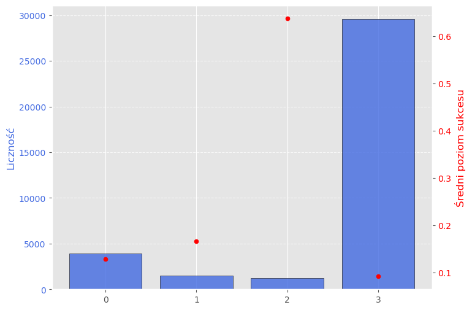

```python
wykres_zaleznosci(X_train,'poutcome',size=25)
```

## Wnioski

Skuteczność kampanii zależy od liczby kontaktów z klientami oraz od wcześniejszych doświadczeń z poprzednimi kampaniami.  
Zbyt częste kontakty mogą prowadzić do zniechęcenia, podczas gdy osoby, z którymi kontaktowano się rzadziej, mają wyższą szansę na pozytywną decyzję.  
Ponadto, klienci, którzy mieli wcześniejsze interakcje z kampanią, są bardziej skłonni do podjęcia decyzji o subskrypcji.  
Zmienne takie jak `previous` i `pdays` mają ograniczoną wartość predykcyjną, szczególnie gdy większość klientów nie miała wcześniejszego kontaktu.  
Jednak klienci, którzy podjęli pozytywną decyzję w poprzednich kampaniach, mają największą szansę na sukces w bieżącej.